[O’Hara on GitHub](https://github.com/oharac)

# Set up master rasters

Compiled on Sat Mar 16 16:36:00 2024 by ohara

```r
knitr::opts_chunk$set(echo = TRUE, message = FALSE, warning = FALSE)

library(terra)
library(sf)
library(oharac)
oharac::setup()
source(here('common_fxns.R'))
```

# 1 Summary

Set up rasters for analysis.

- Global rasters at 10 x 10 km and 1 x 1 km resolution Mollweide CRS.
  - 10 x 10 km raster will double as a cell ID raster.
- Ocean area proportion $\in$ (0, 1], 10 km x 10 km Mollweide
  - create global raster from NE ocean at 1 km x 1 km resolution; aggregate up to 10 km x 10 km
- Coastal area proportion $\in$ (0, 1], 10 km x 10 km Mollweide
  - create global raster from buffered land, at 3 nmi distance, at 1 x 1 km resolution; aggregate up to 10 km x 10 km.
  - can also create one at 1 km buffer.
  - do we need inland buffers?
- Using the 10 km x 10 km ocean area raster as a base, create:
  - EEZ raster
  - MEOW raster
  - Bathymetry raster (to clip species to max depth levels)
  - FAO major fishing areas

# 2 Data

Land and ocean shapefiles from Natural Earth. Free vector and raster map data @ naturalearthdata.com.

# 3 Methods

## 3.1 Master raster 1 km and 10 km

```r
moll_crs <- '+proj=moll +lon_0=0 +x_0=0 +y_0=0 +ellps=WGS84 +datum=WGS84 +units=m'

rast_base_10km_file <- here('_spatial/rast_base_mol_10km.tif')

if(!file.exists(rast_base_10km_file)) {
  x <- rast() %>%
    setValues(1)

  rast_base_10km <- project(x, crs = moll_crs, res = 10000, progress="text")

  writeRaster(rast_base_10km, rast_base_10km_file)
}

### disaggregate 10 x 10 km cells to 1 x 1 km cells
rast_base_1km_file <- here_anx('_spatial/rast_base_moll_1km.tif')

if(!file.exists(rast_base_1km_file)) {
  rast_base_10km <- rast(rast_base_10km_file)

  rast_base_1km <- disaggregate(rast_base_10km, fact = 10, progress = 'text')

  writeRaster(rast_base_1km, rast_base_1km_file)
}
```

## 3.2 Ocean area raster

```r
ocean_1km_file <- here_anx('_spatial/ocean_moll_1km.tif')
# unlink(ocean_1km_file)

if(!file.exists(ocean_1km_file)) {
  message('Processing ocean area at 1 km resolution...')
  ocean_sf <- read_sf(here('_spatial', 'ne_10m_ocean', 'ne_10m_ocean.shp'))

  ocean_moll_sf <- ocean_sf %>%
    st_transform(crs = moll_crs)

  rast_base_moll_1km <- rast(rast_base_1km_file)

  ocean_moll_1km <- rasterize(ocean_moll_sf, rast_base_1km,
                              field = NULL, ### NULL sets all polygons to 1
                              background = NA)

  writeRaster(ocean_moll_1km, filename = ocean_1km_file)
}
```

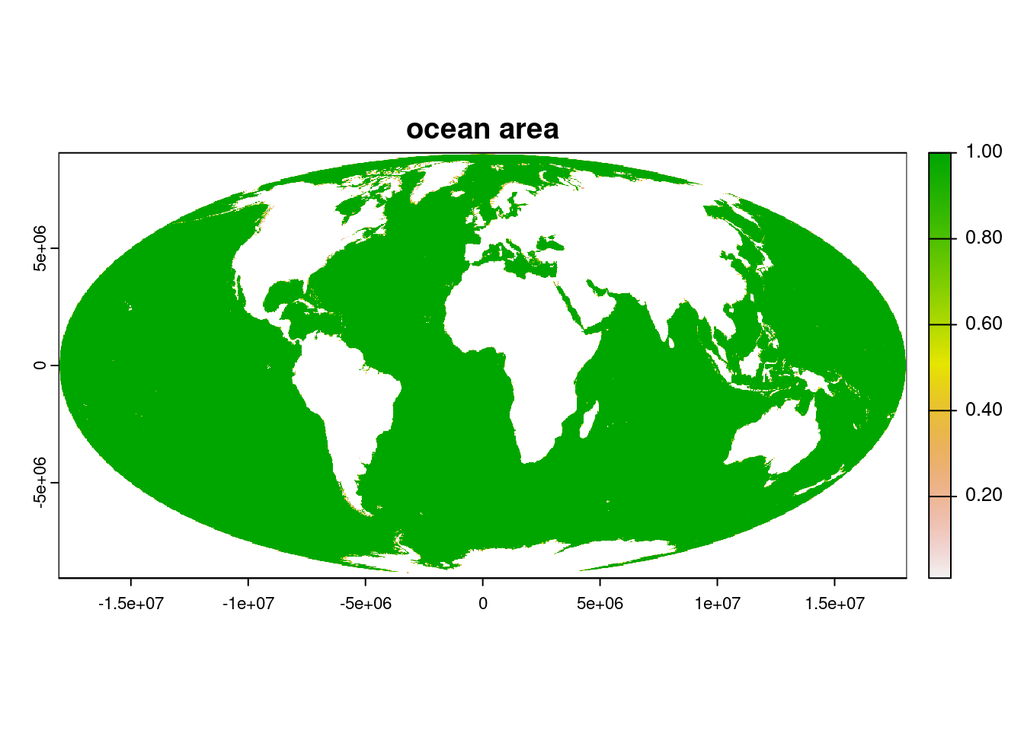

```r
ocean_10km_file <- here('_spatial', 'ocean_area_mol.tif')
# unlink(ocean_10km_file)

if(!file.exists(ocean_10km_file)) {
  message('Processing ocean area at 10 km resolution...')
  ocean_moll_1km <- rast(ocean_1km_file)

  ocean_moll_10km <- aggregate(ocean_moll_1km, fact = 10, fun = sum, progress = 'text')

  # rast_base_10km <- rast(rast_base_10km_file)
  # compareRaster(ocean_moll_10km, rast_base_10km)
  # [1] TRUE

  ### drop the Caspian Sea:
  casp_bbox <- c(xmin = 3700000, xmax = 4800000, ymin = 4300000, ymax = 5650000)
  ocean_moll_df <- as.data.frame(ocean_moll_10km, xy = TRUE) %>%
    setNames(c('x', 'y', 'z')) %>%
    mutate(caspian_x = between(x, casp_bbox['xmin'], casp_bbox['xmax']),
           caspian_y = between(y, casp_bbox['ymin'], casp_bbox['ymax']),
           caspian   = caspian_x & caspian_y) %>%
    mutate(z = ifelse(caspian, NA, z)) %>%
    select(-contains('caspian'))

  ocean_moll_10km_no_casp <- rasterFromXYZ(ocean_moll_df, res = 10000, crs = crs(ocean_moll_10km))

  # plot(ocean_moll_10km_no_casp)
  ocean_moll_10km_no_casp <- ocean_moll_10km_no_casp / 100

  writeRaster(ocean_moll_10km_no_casp, ocean_10km_file, overwrite = TRUE)
}

ocean_moll_10km <- rast(ocean_10km_file)
plot(ocean_moll_10km, main = 'ocean area')
```

## 3.3 Coastal zone rasters

```r
coastal_3nmi_buffer_1km_file <- here_anx('_spatial/coastal_3nmi_buffer_moll_1km.tif')
# unlink(coastal_3nmi_buffer_1km_file)

if(!file.exists(coastal_3nmi_buffer_1km_file)) {
  message('Processing 3 nmi coastal buffer at 1 km resolution...')
  land_sf <- read_sf(here('_spatial', 'ne_10m_land', 'ne_10m_land.shp'))

  land_moll_sf <- land_sf %>%
    st_transform(crs = moll_crs)

  land_3nmi_moll_sf <- land_moll_sf %>%
    st_buffer(dist = 5556) %>% ### 3 nautical miles = 5.556 km
    st_cast('MULTIPOLYGON')

  rast_base_moll_1km <- rast(rast_base_1km_file)

  land_moll_1km <- rasterize(land_3nmi_moll_sf,
                             rast_base_moll_1km,
                             field = NULL, ### NULL sets all polygons to 1
                             background = NA)

  ocean_moll_1km <- rast(here_anx('_spatial/ocean_moll_1km.tif'))

  coastal_3nmi_buffer_1km <- mask(land_moll_1km, ocean_moll_1km, progress = 'text')

  writeRaster(coastal_3nmi_buffer_1km,
              filename = coastal_3nmi_buffer_1km_file)
}
```

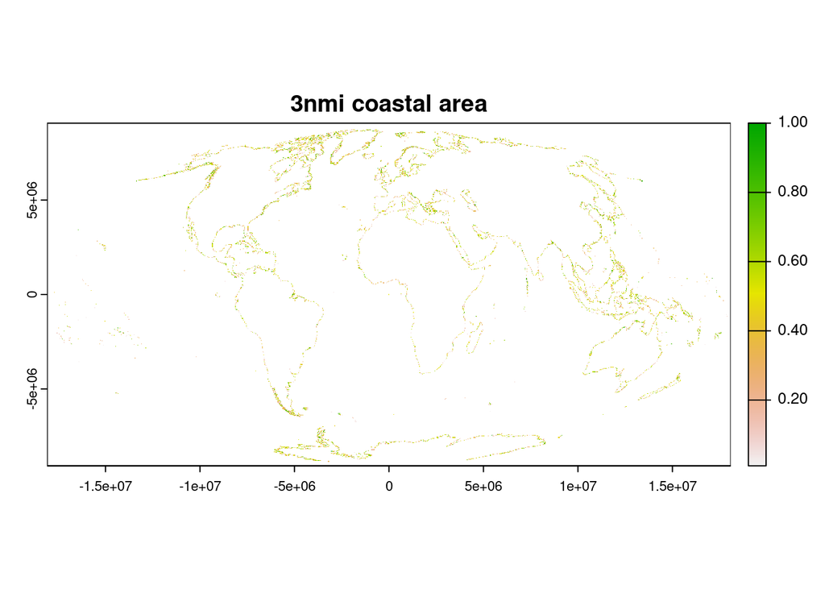

```r
coastal_3nmi_10km_file <- here('_spatial', 'coastal_3nmi_area_mol.tif')
# unlink(coastal_3nmi_10km_file)
if(!file.exists(coastal_3nmi_10km_file)) {
  message('Processing coastal 3 nautical mile buffer area at 10 km resolution...')
  coastal_moll_1km <- rast(coastal_3nmi_buffer_1km_file)

  coastal_moll_10km <- aggregate(coastal_moll_1km, fact = 10, fun = sum, progress = 'text')

  coastal_moll_10km <- coastal_moll_10km / 100

  writeRaster(coastal_moll_10km, coastal_3nmi_10km_file)
}

coastal_moll_10km <- rast(coastal_3nmi_10km_file)
plot(coastal_moll_10km, main = '3nmi coastal area')
```

```r
coastal_1km_buffer_1km_file <- here_anx('_spatial/coastal_1km_buffer_moll_1km.tif')
# unlink(coastal_1km_buffer_1km_file)

if(!file.exists(coastal_1km_buffer_1km_file)) {
  message('Processing 1 km coastal buffer at 1 km resolution...')
  land_sf <- read_sf(here('_spatial', 'ne_10m_land', 'ne_10m_land.shp'))

  land_moll_sf <- land_sf %>%
    st_transform(crs = moll_crs)

  land_1km_moll_sf <- land_moll_sf %>%
    st_buffer(dist = 1000) %>% ###
    st_cast('MULTIPOLYGON')

  rast_base_moll_1km <- rast(rast_base_1km_file)

  land_moll_1km <- rasterize(land_1km_moll_sf,
                             rast_base_moll_1km,
                             field = NULL, ### NULL sets all polygons to 1
                             background = NA)

  ocean_moll_1km <- rast(here_anx('_spatial/ocean_moll_1km.tif'))

  coastal_1km_buffer_1km <- mask(land_moll_1km, ocean_moll_1km, progress = 'text')

  writeRaster(coastal_1km_buffer_1km,
              filename = coastal_1km_buffer_1km_file)
}
```

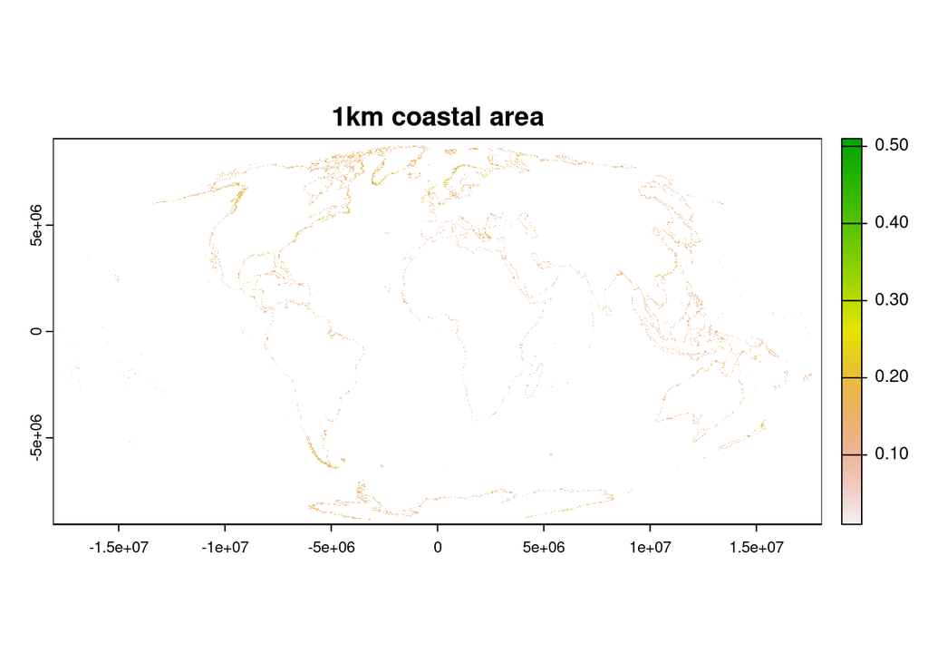

```r
coastal_1km_10km_file <- here('_spatial', 'coastal_1km_area_mol.tif')
# unlink(coastal_1km_10km_file)
if(!file.exists(coastal_1km_10km_file)) {
  message('Processing coastal 1 km buffer area at 10 km resolution...')
  coastal_moll_1km <- rast(coastal_1km_buffer_1km_file)

  coastal_moll_10km <- aggregate(coastal_moll_1km, fact = 10, fun = sum, progress = 'text')

  coastal_moll_10km <- coastal_moll_10km / 100

  writeRaster(coastal_moll_10km, coastal_1km_10km_file)
}

coastal_1km_moll_10km <- rast(coastal_1km_10km_file)
plot(coastal_1km_moll_10km, main = '1km coastal area')
```

## 3.4 LOICZID raster

for projecting AquaMaps to Mollweide CRS

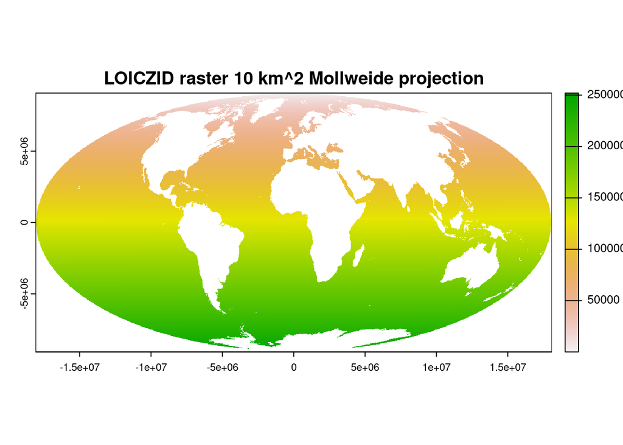

```r
loiczid_rast_file <- here('_spatial', 'loiczid_mol.tif')

if(!file.exists(loiczid_rast_file)) {

  loiczid_rast <- rast(ext = extent(c(xmin = -180, xmax = 180, ymin = -90, ymax = 90)),
                         res = 0.5,
                         crs = '+init=epsg:4326') %>%
    setValues(1:ncell(.))

  ocean_moll_10km <- rast(ocean_10km_file)

  loiczid_moll <- project(loiczid_rast, ocean_moll_10km, method = 'ngb')

  writeRaster(loiczid_moll, loiczid_rast_file, overwrite = TRUE)
  ### this drops some polar cells
  # x <- 1:ncell(loiczid_rast)
  # y <- x[!x %in% values(loiczid_moll)]
  # hist(y)
}

loiczid_moll <- rast(loiczid_rast_file)
plot(mask(loiczid_moll, ocean_moll_10km),
     main = 'LOICZID raster 10 km^2 Mollweide projection')
```

## 3.5 EEZ raster

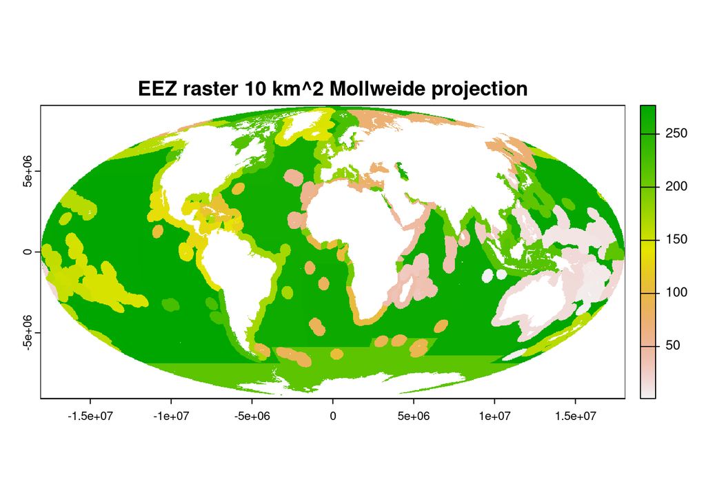

```r
eez_rast_file <- here('_spatial', 'eez_mol.tif')

if(!file.exists(eez_rast_file)) {

  eez_shp_file  <- file.path(here('_spatial/rgns/rgns_mol_1k.gpkg'))
  eez_sf <- read_sf(eez_shp_file)

  eez_df <- eez_sf %>%
    as.data.frame() %>%
    dplyr::select(-geom)
  eez_ids <- eez_df %>%
    select(rgn_id, rgn_name, rgn_ant_id) %>%
    distinct()
  ### rgn_ant_id is same as rgn_id except for Antarctica.  We don't really
  ### need to chunk out Antarctica at this point so just use rgn_id.

  ocean_moll_10km <- rast(ocean_10km_file)

  eez_rast <- rasterize(eez_sf, ocean_moll_10km,
                                   field = 'rgn_id',
                                   fun = 'min')

  eez_rast_ocean <- eez_rast %>%
    mask(ocean_moll_10km)

  writeRaster(eez_rast_ocean, eez_rast_file, overwrite = TRUE)

}
eez_rast_ocean <- rast(eez_rast_file)
plot(eez_rast_ocean, main = 'EEZ raster 10 km^2 Mollweide projection')
```

## 3.6 MEOW raster

Using the MEOW shapefile, we will include all the shapes at the region and province level and then mask out land using the area raster (for consistency).

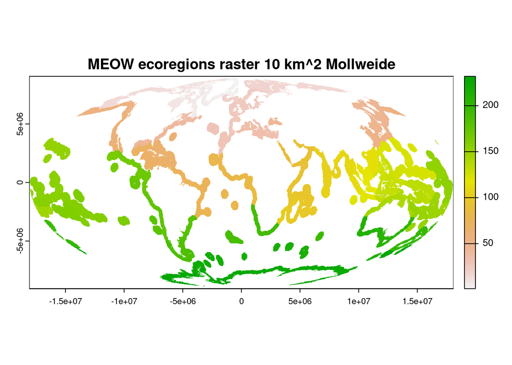

```r
meow_rgn_rast_file <- here('_spatial', 'meow_rgns_mol.tif')

if(!file.exists(meow_rgn_rast_file)) {
  meow_sf <- read_sf(here('_spatial/meow_rgns/meow_rgns.shp'))

  ocean_moll_10km <- rast(ocean_10km_file)

  meow_sf_moll <- meow_sf %>%
    smoothr::densify(max_distance = 0.1) %>%
    select(ECO_CODE_X, geometry) %>%
    st_transform(crs(ocean_moll_10km))

  # plot(meow_sf_moll)

  meow_rast <- rasterize(meow_sf_moll, ocean_moll_10km,
                                   field = 'ECO_CODE_X', fun = 'min')

  meow_rast <- meow_rast %>%
    mask(ocean_moll_10km)

  writeRaster(meow_rast, meow_rgn_rast_file, overwrite = TRUE)
}

meow_rgn_rast <- rast(meow_rgn_rast_file)

plot(meow_rgn_rast, main = 'MEOW ecoregions raster 10 km^2 Mollweide')
```

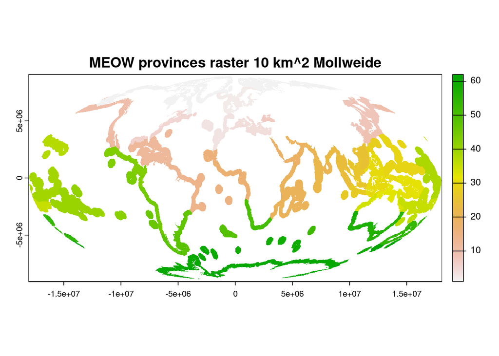

```r
meow_prov_rast_file <- here('_spatial', 'meow_prov_mol.tif')

if(!file.exists(meow_prov_rast_file)) {
  meow_sf <- read_sf(here('_spatial/meow_rgns/meow_rgns.shp'))

  ocean_moll_10km <- rast(ocean_10km_file)

  meow_sf_moll <- meow_sf %>%
    smoothr::densify(max_distance = 0.1) %>%
    select(PROV_CODE, geometry) %>%
    st_transform(crs(ocean_moll_10km))

  # plot(meow_sf_moll)

  meow_rast <- rasterize(meow_sf_moll, ocean_moll_10km,
                                   field = 'PROV_CODE', fun = 'min')

  meow_rast <- meow_rast %>%
    mask(ocean_moll_10km)

  writeRaster(meow_rast, meow_prov_rast_file, overwrite = TRUE)
}

meow_prov_rast <- rast(meow_prov_rast_file)

plot(meow_prov_rast, main = 'MEOW provinces raster 10 km^2 Mollweide')
```

## 3.7 Bathymetry raster

Using [General Bathymetric Chart of the Oceans (GEBCO) bathymetry raster](https://www.bodc.ac.uk/data/hosted_data_systems/gebco_gridded_bathymetry_data/), identify min depth of ocean cells. For neritic and coastal cells, leaving as min depth allows for changing depth thresholds if desired. We will not clip based on anything below 200 m, so can classify these more coarsely.

NOTE: 1 arcmin and 30 arcsec are available; 30 arcsec is more recent but one arcmin should be sufficient for our purposes. Resample to 6 arc-minute (0.10°) using min depth in each cell.

Additionally, to ensure some minimum coastal cell presence, we will include a buffer based on the 3nm coastal zone from OHI.

Bathymetry is masked to the ocean area raster.

### 3.7.1 Create and view minimum depth raster

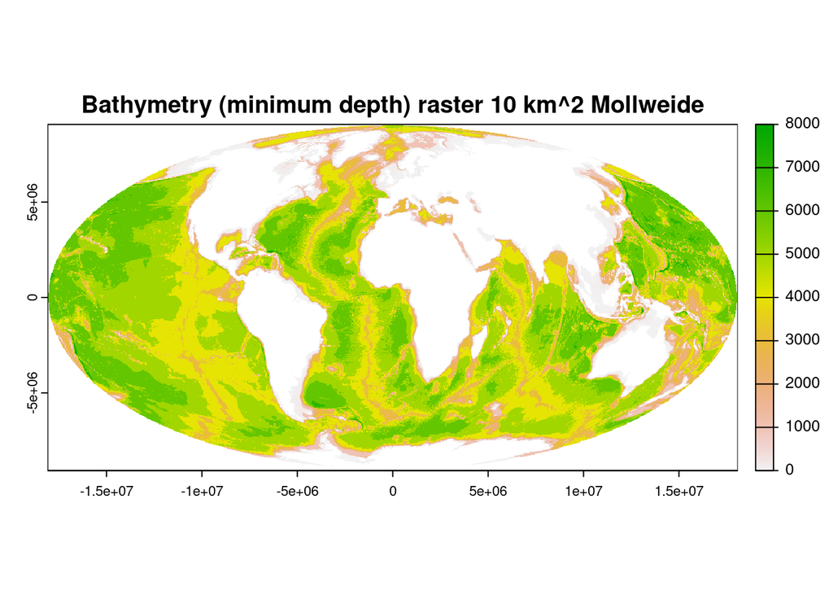

```r
bathy_rast_file <- here('_spatial', 'bathy_mol.tif')


if(!file.exists(bathy_rast_file)) {

  gebco_rast_file <- here_anx('_spatial/gebco/GRIDONE_1D.nc')
  gebco_rast_raw  <- rast(gebco_rast_file)
  ocean_moll_10km <- rast(ocean_10km_file)

  ### The GEBCO raster is elevation, so depth is neg... for min depth,
  ### aggregate by max (and vice versa)
  bathy_rast_min <- gebco_rast_raw %>%
    aggregate(fact = 6, fun = max, progress = 'text')

  bathy_rast_min <- -1 * bathy_rast_min ### depth as positive

  bathy_rast_raw <- bathy_rast_min %>%
    project(ocean_moll_10km,
                  progress = 'text',
                  method = 'ngb')

  ### reclassify:
  ### compress cells above zero to sea level;
  ### compress cells below 200 m to rough depth clips
  bathy_rast <- bathy_rast_raw
  values(bathy_rast)[values(bathy_rast_raw) <    0] <-    0
  values(bathy_rast)[values(bathy_rast_raw) >  200] <- 1000
  values(bathy_rast)[values(bathy_rast_raw) > 1000] <- 2000
  values(bathy_rast)[values(bathy_rast_raw) > 2000] <- 3000
  values(bathy_rast)[values(bathy_rast_raw) > 3000] <- 4000
  values(bathy_rast)[values(bathy_rast_raw) > 4000] <- 5000
  values(bathy_rast)[values(bathy_rast_raw) > 5000] <- 6000
  values(bathy_rast)[values(bathy_rast_raw) > 6000] <- 7000
  values(bathy_rast)[values(bathy_rast_raw) > 7000] <- 8000

  bathy_rast <- bathy_rast %>%
    mask(ocean_moll_10km)

  writeRaster(bathy_rast, bathy_rast_file, overwrite = TRUE)

  ### set up all masks with a base filled with NAs
  coastal_rast <- rast(coastal_3nmi_10km_file)
  rast_neritic <- rast_shallow <- rast(bathy_rast)
  values(rast_neritic)[values(bathy_rast) <= 200] <- 1
  values(rast_neritic)[!is.na(values(coastal_rast))] <- 1
  values(rast_shallow)[values(bathy_rast) <=  60] <- 1
  values(rast_shallow)[!is.na(values(coastal_rast))] <- 1

  writeRaster(rast_neritic, here('_spatial', 'bathy_mol_neritic.tif'),
              overwrite = TRUE)
  writeRaster(rast_shallow, here('_spatial', 'bathy_mol_shallow.tif'),
              overwrite = TRUE)

}

bathy_rast <- rast(bathy_rast_file)

plot(bathy_rast, main = 'Bathymetry (minimum depth) raster 10 km^2 Mollweide')
```

## 3.8 FAO regions raster

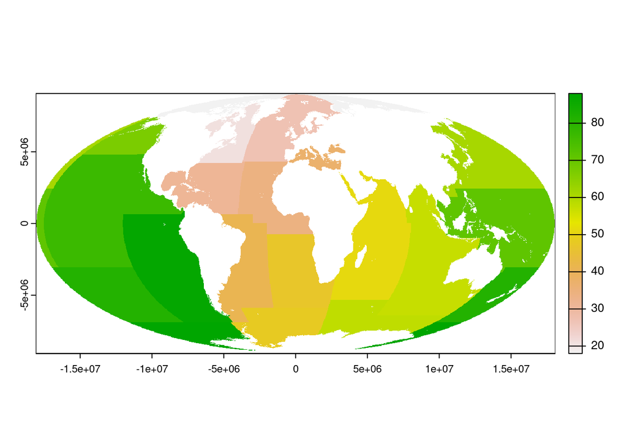

```r
fao_rast_f <- here('_spatial/fao_mol.tif')

if(!file.exists(fao_rast_f)) {
  fao_shp_f <- here_anx('../fao_rgns/World_Fao_Zones.shp')
  fao_rgns <- read_sf(fao_shp_f) %>%
    smoothr::densify(max_distance = .5) %>%
      ### a vertex every .5 degrees ought to do it
    st_transform(st_crs(loiczid_moll))

  fao_rast <- rasterize(fao_rgns, loiczid_moll, field = 'zone')

  writeRaster(fao_rast, fao_rast_f)
}

fao_rast <- rast(fao_rast_f)
plot(fao_rast)
```